# 20201204-p8122_hw4_jsg2145

Jared Garfinkel

12/4/2020

```r
data = read_tsv("./data/gardasil.dat.txt") %>%
  janitor::clean_names() %>%
  select(-c(x11:x12))
data
```

```
## # A tibble: 1,413 x 10
##      age age_group  race shots completed insurance_type med_assist location
##    <dbl>     <dbl> <dbl> <dbl>     <dbl>          <dbl>      <dbl>    <dbl>
##  1    21         1     0     3         1              3          0        1
##  2    21         1     0     3         1              3          0        1
##  3    20         1     0     1         0              1          0        1
##  4    14         0     0     3         1              3          0        1
##  5    17         0     3     2         0              3          0        1
##  6    11         0     1     1         0              0          1        1
##  7    17         0     0     1         0              3          0        1
##  8    15         0     3     3         1              1          0        1
##  9    13         0     3     3         1              1          0        1
## 10    18         1     0     3         1              2          0        1
## # ... with 1,403 more rows, and 2 more variables: location_type <dbl>,
## #   practice_type <dbl>
```

There are 1413 rows by 10 columns in the dataset.

```r
skimr::skim(data)
```

Data summary

| Name | data |
| --- | --- |
| Number of rows | 1413 |
| Number of columns | 10 |
| _______________________ |  |
| Column type frequency: |  |
| numeric | 10 |
| ________________________ |  |
| Group variables | None |

**Variable type: numeric**

| skim_variable | n_missing | complete_rate | mean | sd | p0 | p25 | p50 | p75 | p100 | hist |
| --- | --- | --- | --- | --- | --- | --- | --- | --- | --- | --- |
| age | 0 | 1 | 18.55 | 4.23 | 11 | 15 | 18 | 22 | 26 | ▆▇▆▅▅ |
| age_group | 0 | 1 | 0.50 | 0.50 | 0 | 0 | 1 | 1 | 1 | ▇▁▁▁▇ |
| race | 0 | 1 | 0.78 | 1.02 | 0 | 0 | 0 | 1 | 3 | ▇▅▁▁▂ |
| shots | 0 | 1 | 2.07 | 0.83 | 1 | 1 | 2 | 3 | 3 | ▆▁▆▁▇ |
| completed | 0 | 1 | 0.33 | 0.47 | 0 | 0 | 0 | 1 | 1 | ▇▁▁▁▃ |
| insurance_type | 0 | 1 | 1.33 | 1.04 | 0 | 1 | 1 | 2 | 3 | ▃▇▁▁▃ |
| med_assist | 0 | 1 | 0.19 | 0.40 | 0 | 0 | 0 | 0 | 1 | ▇▁▁▁▂ |
| location | 0 | 1 | 2.01 | 1.28 | 1 | 1 | 1 | 4 | 4 | ▇▂▁▁▃ |
| location_type | 0 | 1 | 0.32 | 0.47 | 0 | 0 | 0 | 1 | 1 | ▇▁▁▁▃ |
| practice_type | 0 | 1 | 1.01 | 0.86 | 0 | 0 | 1 | 2 | 2 | ▇▁▆▁▇ |

There is no missing data.

The ages range from 11 to 26 with a median age of 18 years old.

There is a categorical variable, age_group, that categorizes patients by age. It appears that this variable uses 18 years old as a cutoff for adulthood.

There is a variable for race that appears to include 4 races, “0”, “1”, “2”, and “3”.

The variable shots ranges from 1 to 3.

There are 4 different insurance types, med_assist (0 or 1), location (1, 2, 3, or 4), location type (0 or 1), and practice type (0, 1, or 2).

All the variables are categorical except for age, which has been split into age_group.

# Part 1

The outcome variable (completed) is removed from the dataset.

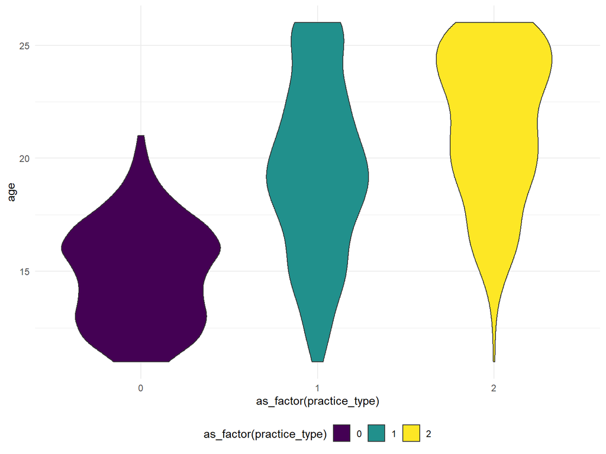

```r
data %>%
  select(-completed) %>%
  ggplot(aes(x = as_factor(practice_type), y = age, fill = as_factor(practice_type))) +
  geom_violin()
```

```r
xtabs(~ practice_type + race, data = data)
```

```
##              race
## practice_type   0   1   2   3
##             0 232 194  29  60
##             1 169 102  10  84
##             2 331 147  13  42
```

```r
xtabs(~practice_type + insurance_type, data = data)
```

```
##              insurance_type
## practice_type   0   1   2   3
##             0 204 171  25 115
##             1  12 188   9 156
##             2  59 364  50  60
```

```r
xtabs(~practice_type + med_assist, data = data)
```

```
##              med_assist
## practice_type   0   1
##             0 311 204
##             1 353  12
##             2 474  59
```

```r
xtabs(~practice_type + location, data = data)
```

```
##              location
## practice_type   1   2   3   4
##             0 216   0   0 299
##             1 365   0   0   0
##             2 217 165  89  62
```

```r
xtabs(~practice_type + location_type, data = data)
```

```
##              location_type
## practice_type   0   1
##             0 216 299
##             1 365   0
##             2 382 151
```

```r
xtabs(~practice_type + age_group, data = data)
```

```
##              age_group
## practice_type   0   1
##             0 482  33
##             1 123 242
##             2  96 437
```

There is sparse data in the practice type and location type cross tabulation and in the practice type and insurance type cross tabulation.

It appears that patients who go to practice_type “2” tend to be older than those who go to practice_type “0”.

```r
vars = c("age", "age_group", "race", "insurance_type", "med_assist", "location", "location_type")
covbal0 <- CreateTableOne(vars = vars, strata = "practice_type", data = data, test = FALSE, smd=TRUE)
print(covbal0, smd = TRUE)
```

```
##                             Stratified by practice_type
##                              0            1            2            SMD
##   n                            515          365          533
##   age (mean (SD))            14.92 (2.25) 19.46 (3.82) 21.43 (3.33)  1.429
##   age_group (mean (SD))       0.06 (0.25)  0.66 (0.47)  0.82 (0.38)  1.432
##   race (mean (SD))            0.84 (0.97)  1.02 (1.19)  0.56 (0.88)  0.305
##   insurance_type (mean (SD))  1.10 (1.15)  1.85 (1.03)  1.21 (0.78)  0.498
##   med_assist (mean (SD))      0.40 (0.49)  0.03 (0.18)  0.11 (0.31)  0.661
##   location (mean (SD))        2.74 (1.48)  1.00 (0.00)  1.99 (1.02)  1.209
##   location_type (mean (SD))   0.58 (0.49)  0.00 (0.00)  0.28 (0.45)  1.060
```

# Part 2

In an RCT the eligibility criteria and treatment and control arm are prespecified.

The treatment arm can be those who attend the OB-GYN and the control arm can be those who go to a general practice or pediatrician.

To find the rates of completion at different types of practices, we are interested in achieving the following properties for the assignment mechanism:

1. Individualistic
2. Probabilistic
3. Unconfounded
4. Known and controlled

In order to make this observational study probabilistic, we can make ineligible those who attend a pediatrician, who will almost always be younger than those who do not. This eliminates those in practice type “0”, n = 515.

# Part 3

```r
data2 = data %>%
  filter(practice_type!=0) %>%
  mutate(practice_type = recode(practice_type,
                                "1" = "0",
                                "2" = "1"),
         practice_type = as.numeric(practice_type))
covbal1 <- CreateTableOne(vars = vars, strata = "practice_type", data = data2, test = FALSE, smd=TRUE)
print(covbal1, smd = TRUE)
```

```
##                             Stratified by practice_type
##                              0            1            SMD
##   n                            365          533
##   age (mean (SD))            19.46 (3.82) 21.43 (3.33)  0.548
##   age_group (mean (SD))       0.66 (0.47)  0.82 (0.38)  0.364
##   race (mean (SD))            1.02 (1.19)  0.56 (0.88)  0.444
##   insurance_type (mean (SD))  1.85 (1.03)  1.21 (0.78)  0.699
##   med_assist (mean (SD))      0.03 (0.18)  0.11 (0.31)  0.305
##   location (mean (SD))        1.00 (0.00)  1.99 (1.02)  1.375
##   location_type (mean (SD))   0.00 (0.00)  0.28 (0.45)  0.888
```

# Part 4

## fit propensity score model

At first there were over one hundred observations with a propensity score of 1.0.

This may be problematic because it means that there may be confounders that could affect which practice type one attends and the outcome of interest as well as the location of the patient.

```r
ps.model <- glm(practice_type ~ age + age_group + race + insurance_type + med_assist + location + location_type, data = data2, family = binomial)
summary(ps.model)
```

```
##
## Call:
## glm(formula = practice_type ~ age + age_group + race + insurance_type +
##     med_assist + location + location_type, family = binomial,
##     data = data2)
##
## Deviance Residuals:
##      Min        1Q    Median        3Q       Max
## -1.48886  -0.78203   0.00006   0.00022   1.99238
##
## Coefficients:
##                  Estimate Std. Error z value Pr(>|z|)
## (Intercept)     -21.95072  624.84667  -0.035  0.97198
## age               0.13964    0.03986   3.503  0.00046 ***
## age_group        -0.01471    0.34232  -0.043  0.96572
## race             -0.26503    0.08324  -3.184  0.00145 **
## insurance_type   -0.30932    0.10102  -3.062  0.00220 **
## med_assist       -1.69664    0.80281  -2.113  0.03457 *
## location         19.35170  624.84618   0.031  0.97529
## location_type   -19.01966 1436.00949  -0.013  0.98943
## ---
## Signif. codes:  0 '***' 0.001 '**' 0.01 '*' 0.05 '.' 0.1 ' ' 1
##
## (Dispersion parameter for binomial family taken to be 1)
##
##     Null deviance: 1213.28  on 897  degrees of freedom
## Residual deviance:  701.13  on 890  degrees of freedom
## AIC: 717.13
##
## Number of Fisher Scoring iterations: 18
```

```r
ps <- predict(ps.model, type="response")
```

```r
prop.func <- function(x = data2, trt = treat) {
  # fit propensity score model
  propens.model <- glm(practice_type ~ age + age_group + race + insurance_type + med_assist + location + location_type, data = x, family = binomial)
  pi.x <- predict(propens.model, type = "response")
  return(pi.x)
}
```

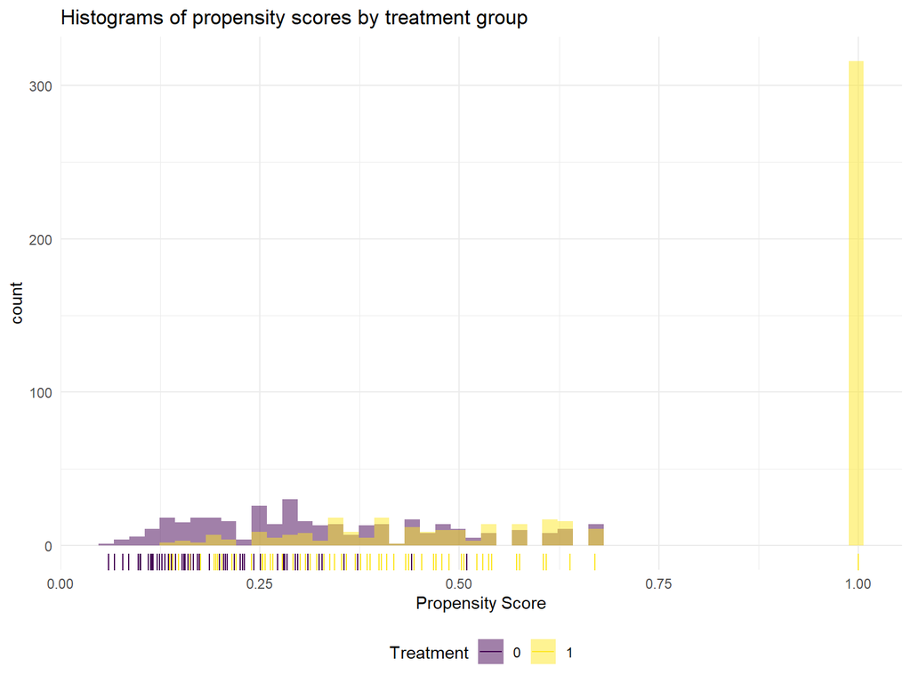

```r
check.overlap(x = data2,
              trt = data2$practice_type,
              propensity.func = prop.func)
```

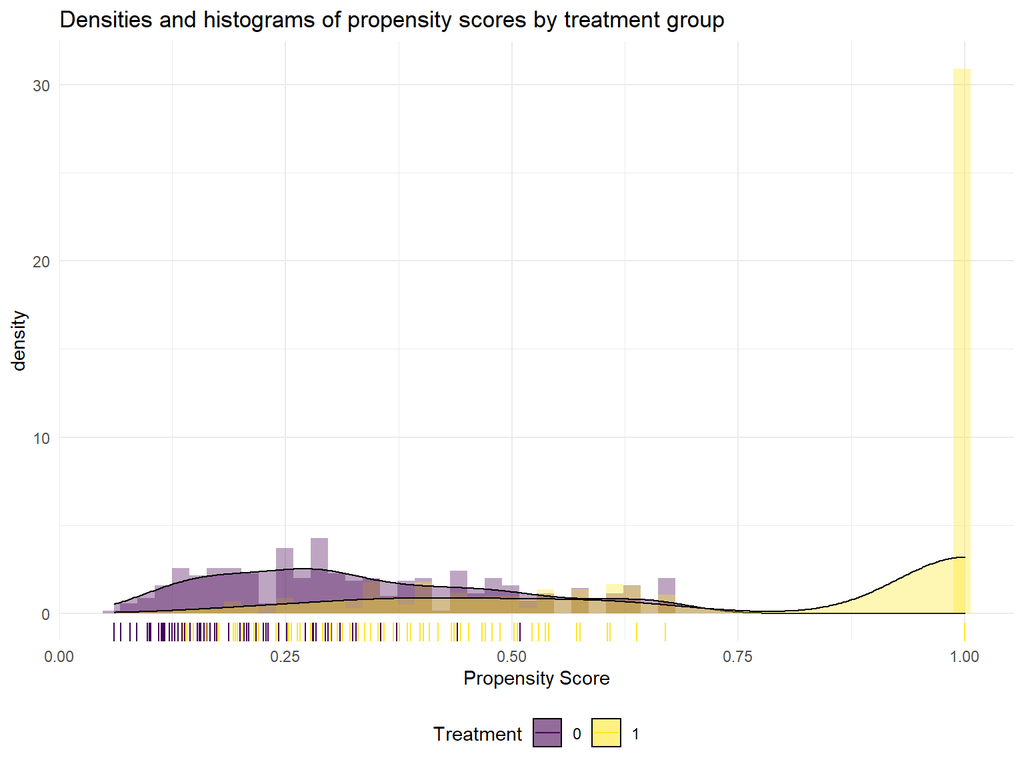

```r
check.overlap(x = data2,
              trt = data2$practice_type,
              type = "both",
              propensity.func = prop.func)
```

# Part 5

```r
min(ps[data2$practice_type==1])
ps[which(data2$practice_type==0)] <= min(ps[data2$practice_type==1])

max(ps[data2$practice_type==0])
ps[which(data2$practice_type==1)] >= max(ps[data2$practice_type==0])
```

```r
df = data2[ps>=min(ps[data2$practice_type==1]) & ps <= max(ps[data2$practice_type==0]),]
dim(df)
```

```
## [1] 546  10
```

```r
dim(data2)
```

```
## [1] 898  10
```

There are 546 patients in the final analytical sample compared to 898 in the original model with eligible patients only. There were 352 patients excluded during trimming. This is also 867 fewer patients than the original sample.

```r
### refitting propensity score model
ps.model2<-glm(practice_type ~ age + age_group + race + shots + insurance_type + med_assist + location + location_type, data=df , family = binomial)
summary(ps.model2)
```

```
##
## Call:
## glm(formula = practice_type ~ age + age_group + race + shots +
##     insurance_type + med_assist + location + location_type, family = binomial,
##     data = df)
##
## Deviance Residuals:
##     Min       1Q   Median       3Q      Max
## -1.4549  -0.9801  -0.7260   1.1785   1.8984
##
## Coefficients: (2 not defined because of singularities)
##                 Estimate Std. Error z value Pr(>|z|)
## (Intercept)    -2.403914   0.783390  -3.069 0.002151 **
## age             0.132390   0.040136   3.299 0.000972 ***
## age_group      -0.143351   0.344024  -0.417 0.676905
## race           -0.222432   0.085476  -2.602 0.009261 **
## shots           0.007607   0.113063   0.067 0.946355
## insurance_type -0.285503   0.101412  -2.815 0.004873 **
## med_assist     -0.774679   0.941694  -0.823 0.410710
## location              NA         NA      NA       NA
## location_type         NA         NA      NA       NA
## ---
## Signif. codes:  0 '***' 0.001 '**' 0.01 '*' 0.05 '.' 0.1 ' ' 1
##
## (Dispersion parameter for binomial family taken to be 1)
##
##     Null deviance: 733.78  on 545  degrees of freedom
## Residual deviance: 690.73  on 539  degrees of freedom
## AIC: 704.73
##
## Number of Fisher Scoring iterations: 4
```

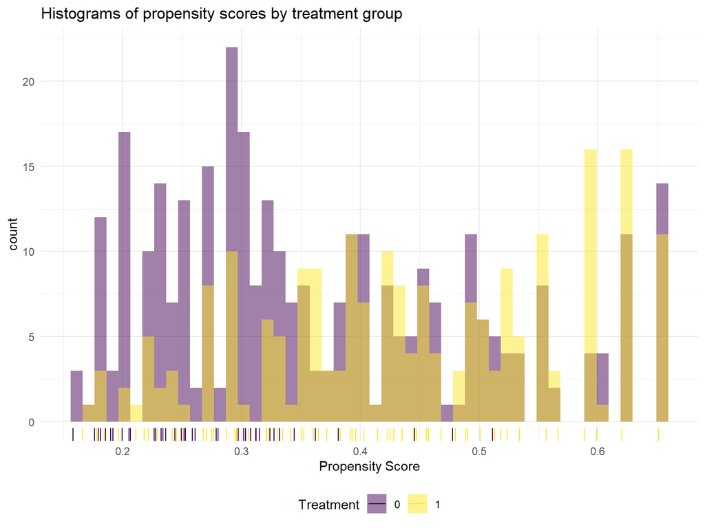

```r
ps2 <- predict(ps.model2, type="response") #gets the propensity scores for each unit, based on the model
check.overlap(x = df,
              trt = df$practice_type,
              propensity.func = prop.func)
```

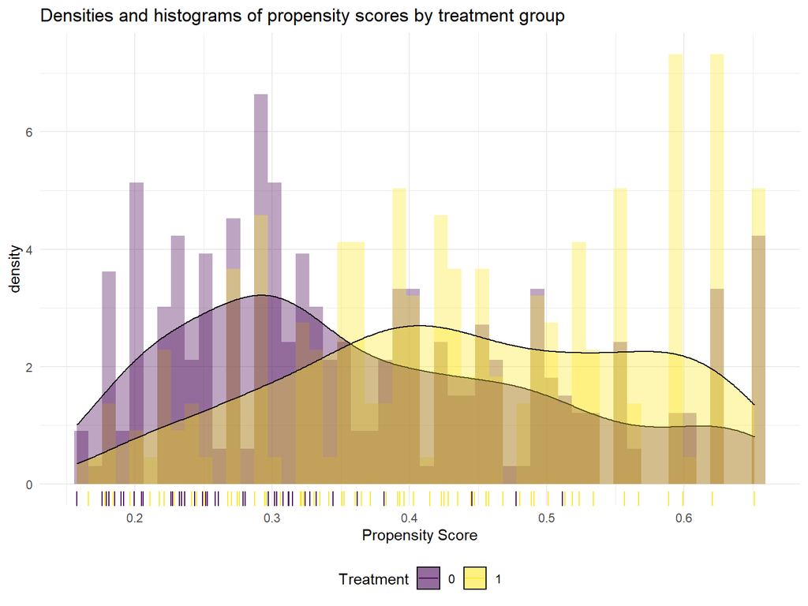

```r
check.overlap(x = df,
              trt = df$practice_type,
              type = "both",
              propensity.func = prop.func)
```

```r
psmatch1 <- matchit(practice_type ~ age + age_group + race + insurance_type + med_assist + location + location_type,
                    distance="logit", method = "nearest", discard = "control", data = df)

psmatch1.data <- match.data(psmatch1)
```

# Part 6

```r
psmatch1.mod <- svyglm(completed ~ practice_type + age + age_group + race + insurance_type + med_assist + location + location_type,
                       design = svydesign(~ 1, weights = ~ weights, data = psmatch1.data))
summary(psmatch1.mod)
```

```
##
## Call:
## svyglm(formula = completed ~ practice_type + age + age_group +
##     race + insurance_type + med_assist + location + location_type,
##     design = svydesign(~1, weights = ~weights, data = psmatch1.data))
##
## Survey design:
## svydesign(~1, weights = ~weights, data = psmatch1.data)
##
## Coefficients: (2 not defined because of singularities)
##                 Estimate Std. Error t value Pr(>|t|)
## (Intercept)     0.527544   0.169728   3.108  0.00201 **
## practice_type   0.048734   0.042405   1.149  0.25109
## age            -0.005293   0.009092  -0.582  0.56073
## age_group      -0.111611   0.089225  -1.251  0.21166
## race           -0.029398   0.019543  -1.504  0.13324
## insurance_type -0.026594   0.023934  -1.111  0.26713
## med_assist     -0.282537   0.047210  -5.985  4.6e-09 ***
## ---
## Signif. codes:  0 '***' 0.001 '**' 0.01 '*' 0.05 '.' 0.1 ' ' 1
##
## (Dispersion parameter for gaussian family taken to be 0.1948005)
##
## Number of Fisher Scoring iterations: 2
```

Therefore, we do not reject the null that there is no causal effect of practice type on completion of the vaccine.

# Part 7

```r
psmatch1c <- matchit(practice_type ~ age + age_group + race + insurance_type + med_assist + location + location_type,
                    distance="logit", method = "nearest",estimand="ATC", data = df)
psmatch1c.data <- match.data(psmatch1c)
```

```r
psmatch1c.mod <- svyglm(completed ~ practice_type + age + age_group + race + insurance_type + med_assist + location + location_type,
                       design = svydesign(~ 1, weights = ~ weights, data = psmatch1c.data))
summary(psmatch1c.mod)
```

```
##
## Call:
## svyglm(formula = completed ~ practice_type + age + age_group +
##     race + insurance_type + med_assist + location + location_type,
##     design = svydesign(~1, weights = ~weights, data = psmatch1c.data))
##
## Survey design:
## svydesign(~1, weights = ~weights, data = psmatch1c.data)
##
## Coefficients: (2 not defined because of singularities)
##                 Estimate Std. Error t value Pr(>|t|)
## (Intercept)     0.604334   0.170767   3.539 0.000446 ***
## practice_type   0.039877   0.042503   0.938 0.348665
## age            -0.008238   0.009149  -0.900 0.368453
## age_group      -0.106701   0.089401  -1.194 0.233331
## race           -0.030333   0.019565  -1.550 0.121802
## insurance_type -0.031763   0.023959  -1.326 0.185635
## med_assist     -0.287479   0.047461  -6.057 3.04e-09 ***
## ---
## Signif. codes:  0 '***' 0.001 '**' 0.01 '*' 0.05 '.' 0.1 ' ' 1
##
## (Dispersion parameter for gaussian family taken to be 0.196103)
##
## Number of Fisher Scoring iterations: 2
```

Therefore, we do not reject that null that there is no causal effect of practice type on completion of the vaccine.

## ATE

```r
psmatch_ate <- matchit(practice_type ~ age + age_group + race + insurance_type + med_assist + location + location_type,
                       data = df,
                       distance = "logit",
                       estimand = "ATE")
```

```r
psmatchate.data <- match.data(psmatch_ate)
psmatchate.mod <- svyglm(completed ~ practice_type + age + age_group + race + insurance_type + med_assist + location + location_type,
                         design = svydesign(~ 1, weights = ~ weights,data=psmatchate.data))
summary(psmatchate.mod)
```

```
##
## Call:
## svyglm(formula = completed ~ practice_type + age + age_group +
##     race + insurance_type + med_assist + location + location_type,
##     design = svydesign(~1, weights = ~weights, data = psmatchate.data))
##
## Survey design:
## svydesign(~1, weights = ~weights, data = psmatchate.data)
##
## Coefficients: (2 not defined because of singularities)
##                 Estimate Std. Error t value Pr(>|t|)
## (Intercept)     0.545547   0.172037   3.171  0.00163 **
## practice_type   0.032307   0.042901   0.753  0.45183
## age            -0.007815   0.009307  -0.840  0.40152
## age_group      -0.064389   0.089718  -0.718  0.47335
## race           -0.031779   0.019987  -1.590  0.11259
## insurance_type -0.017128   0.024403  -0.702  0.48312
## med_assist     -0.276009   0.047314  -5.834 1.07e-08 ***
## ---
## Signif. codes:  0 '***' 0.001 '**' 0.01 '*' 0.05 '.' 0.1 ' ' 1
##
## (Dispersion parameter for gaussian family taken to be 0.2001141)
##
## Number of Fisher Scoring iterations: 2
```

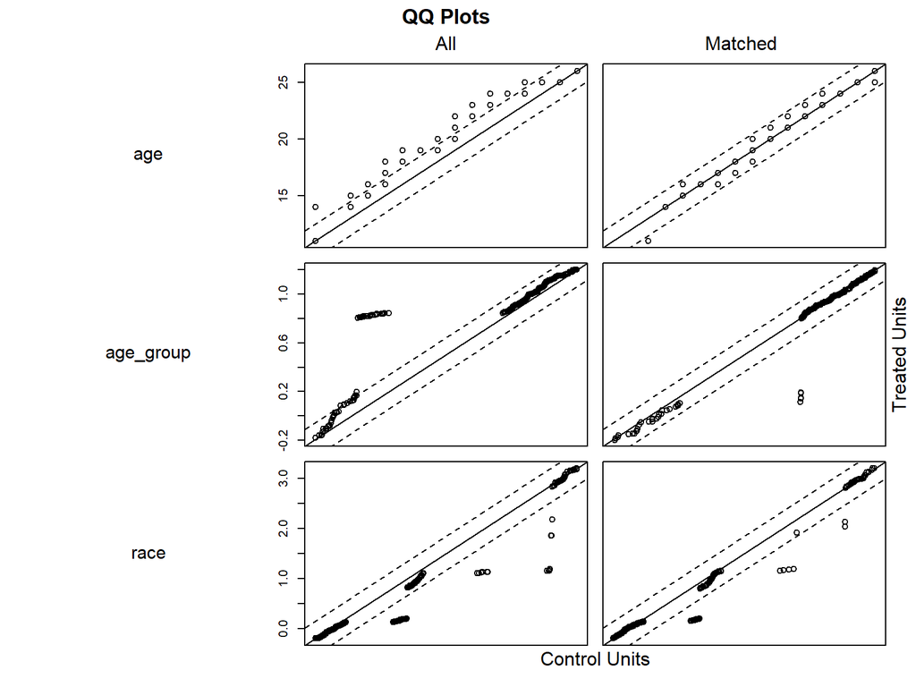

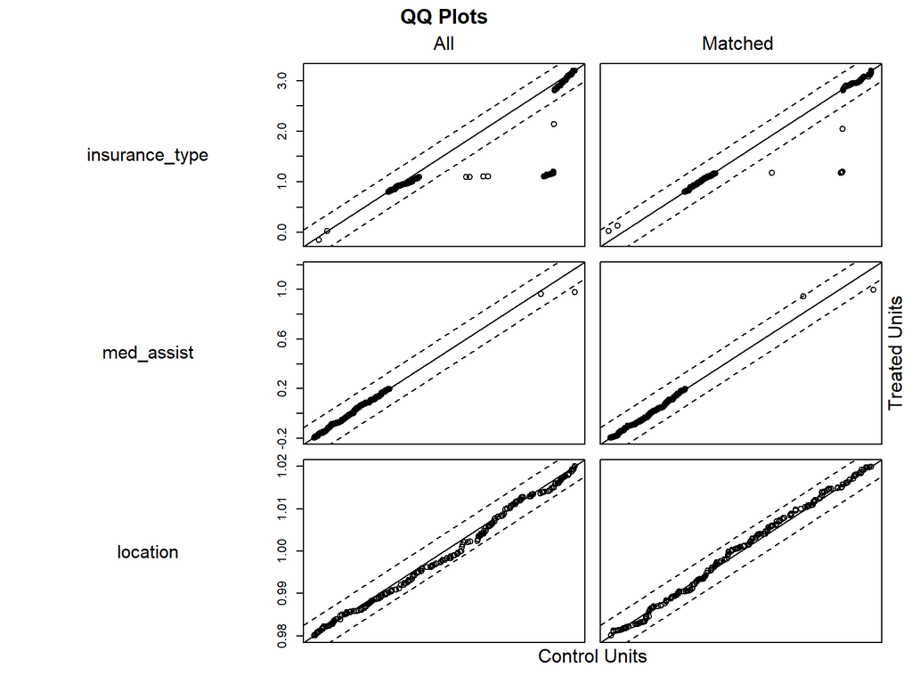

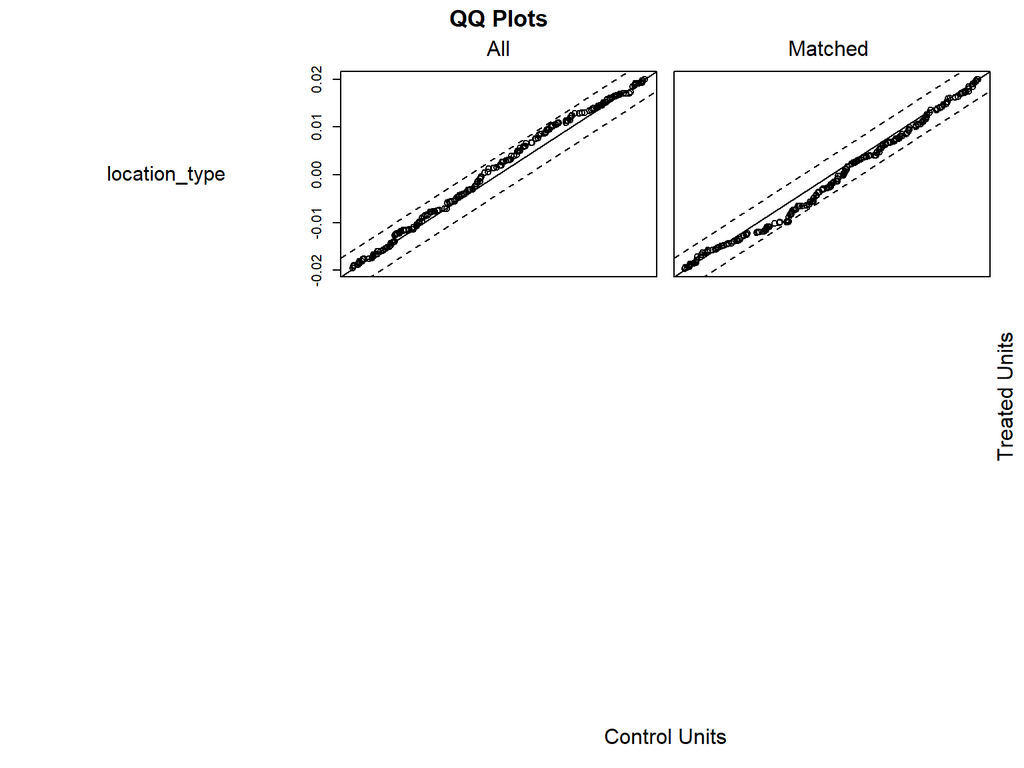

```r
plot(psmatch_ate)
```

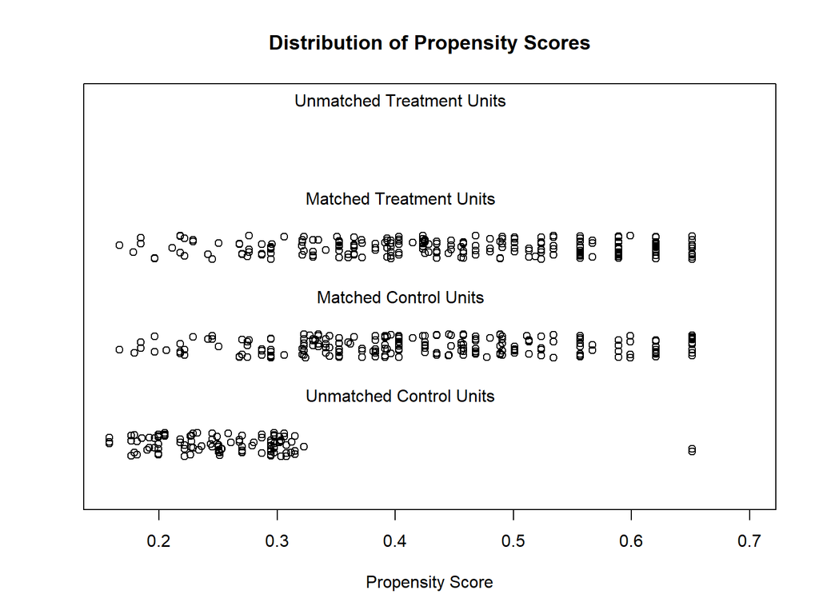

```r
plot(psmatch_ate, type="jitter", interactive = FALSE)
```

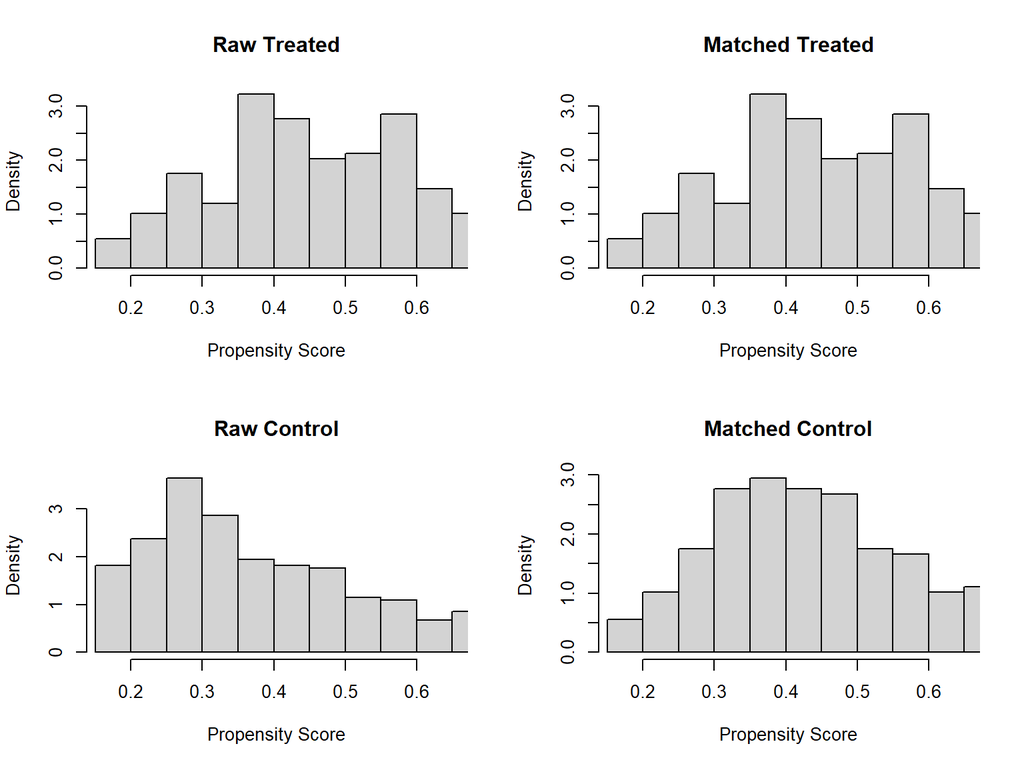

```r
plot(psmatch_ate, type="hist")
```

An average treatment effect (ATE) analysis shows that there is not evidence to reject the null.

Therefore, we accept the null that there is no causal effect of practice type on completion of the vaccine.